# Introduction to ggplot

Peter Freeman (2019 SLSW)

24 June 2019

# Preliminaries

Let’s read in the data frame that we use in the `dplyr` notes set:

```r
df = read.csv("http://www.stat.cmu.edu/~pfreeman/GalaxyMass.csv")
```

As a reminder, these data consist of 3456 rows and 10 columns with names

```r
names(df)
```

```
##  [1] "field"  "Gini"   "M20"    "C"      "A"      "size"   "n"
##  [8] "q"      "z.mode" "mass"
```

# ggplot

`ggplot` (actually, and perhaps confusingly, `ggplot2`) is “a system for declaratively creating graphics, based on The Grammar of Graphics. You provide the data [frame], tell `ggplot2` how to map variables to aesthetics, what graphical primitives to use, and it takes care of the details.”

Sounds good. Let’s dive in:

```r
library(tidyverse)
```

# ggplot: Basic Structure

A very basic call to `ggplot()` has the following structure:

```
ggplot(data=<data frame>,mapping=aes(x=<x axis variable>,...)) + geom_<plot type>(<arguments>)
```

# ggplot: Bar Chart

How many galaxies are in each field?

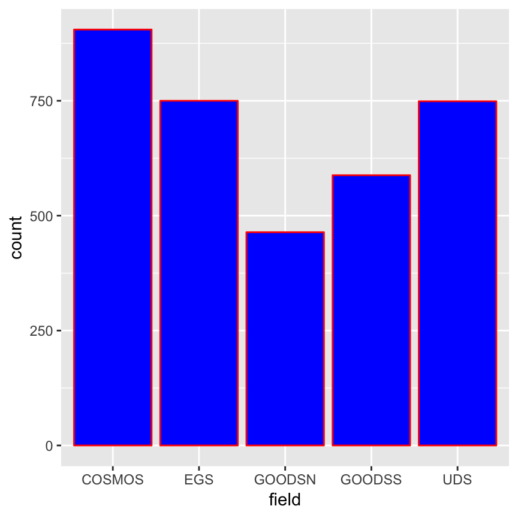

```r
ggplot(data=df,mapping=aes(x=field)) + geom_bar(color="red",fill="blue")
```

(A bar chart is appropriate when the x-axis variable is categorical and the y-axis variable is quantitative.) You can extract the same information in non-visual form using a call to `table()`:

```r
df %>% select(.,field) %>% table(.)
```

```
## .
## COSMOS    EGS GOODSN GOODSS    UDS
##    905    750    464    588    749
```

# ggplot: Histogram

What is the distribution of galaxy sizes?

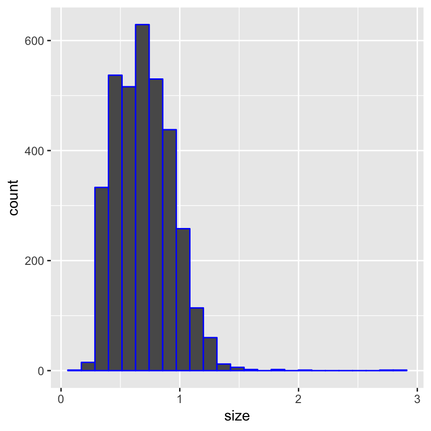

```r
ggplot(data=df,mapping=aes(x=size)) + geom_histogram(color="blue",bins=25)
```

(A histogram is appropriate when the single variable in question is quantitative.)

# ggplot: Boxplot

Boxplots are just a bit trickier. What is the distribution of galaxy concentrations?

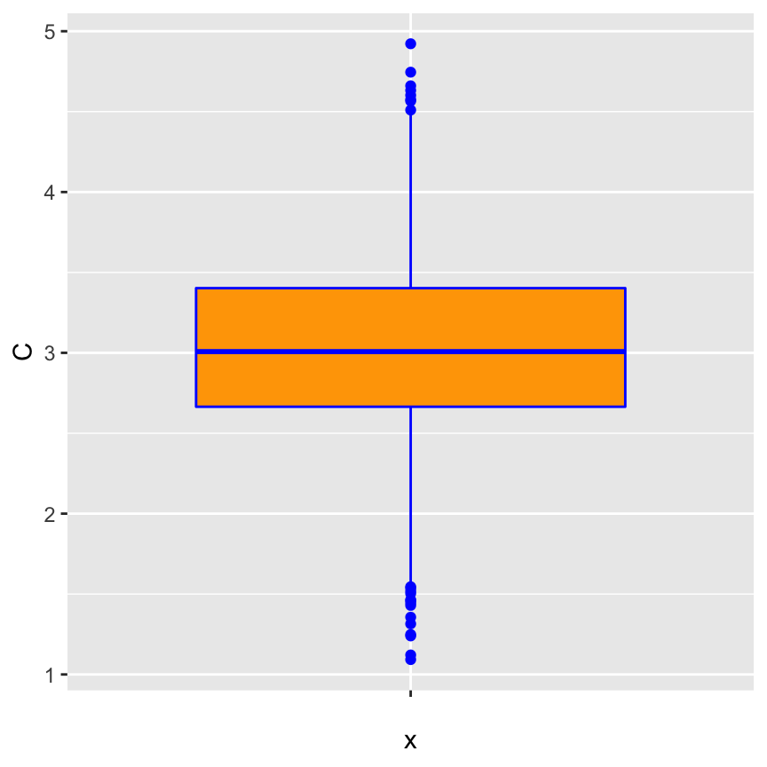

```r
ggplot(data=df,mapping=aes(x="",y=C)) + geom_boxplot(color="blue",fill="orange")
```

Note the empty string for `x`. (A boxplot is also for visualizing a quantitative variable.)

# ggplot: Side-By-Side Boxplots

We can group the data given the values of a categorical variable to create side-by-side boxplots:

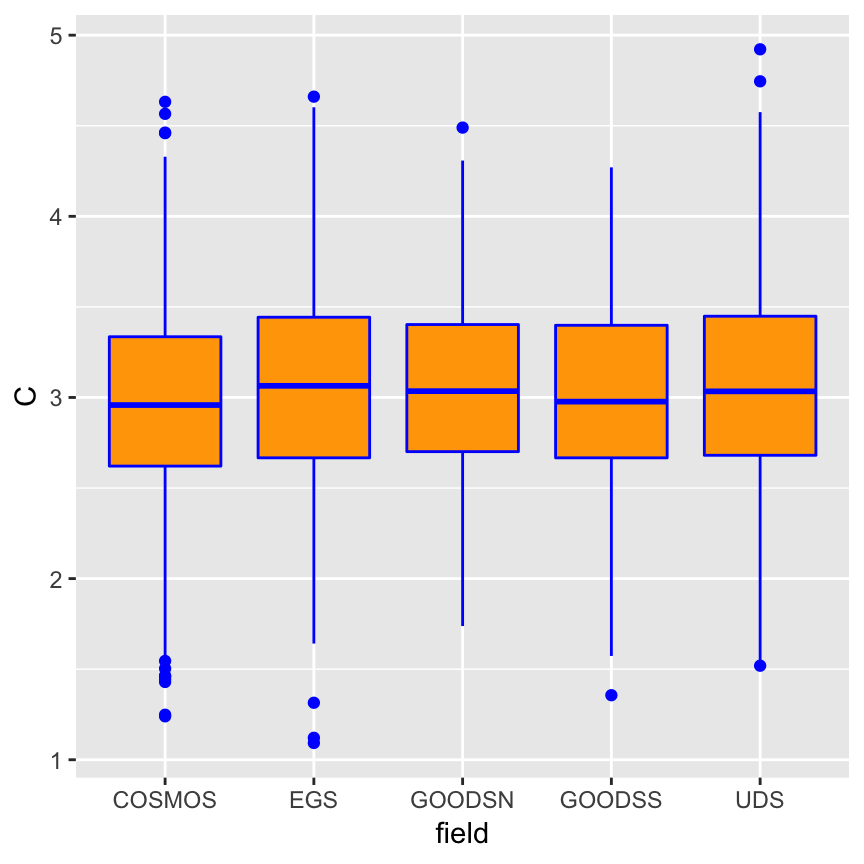

```r
ggplot(data=df,mapping=aes(x=field,y=C)) + geom_boxplot(color="blue",fill="orange")
```

# ggplot: Faceting

Faceting is the act of making multiple plots at once that appear side-by-side as “facets”. Faceting is something you might want to do when, e.g., you have a factor variable. Here, we show histograms of the concentration variable `C` broken up by galaxy field.

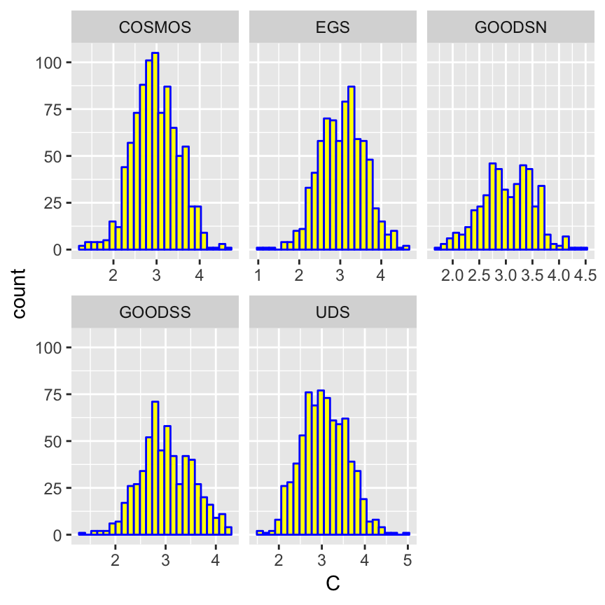

```r
ggplot(data=df,mapping=aes(x=C)) + geom_histogram(color="blue",fill="yellow",bins=25) +
facet_wrap(~field,scales='free_x')
```

# ggplot: Scatter Plot

Is there any visually apparent association between the mass of a galaxy and the concentration of its light?

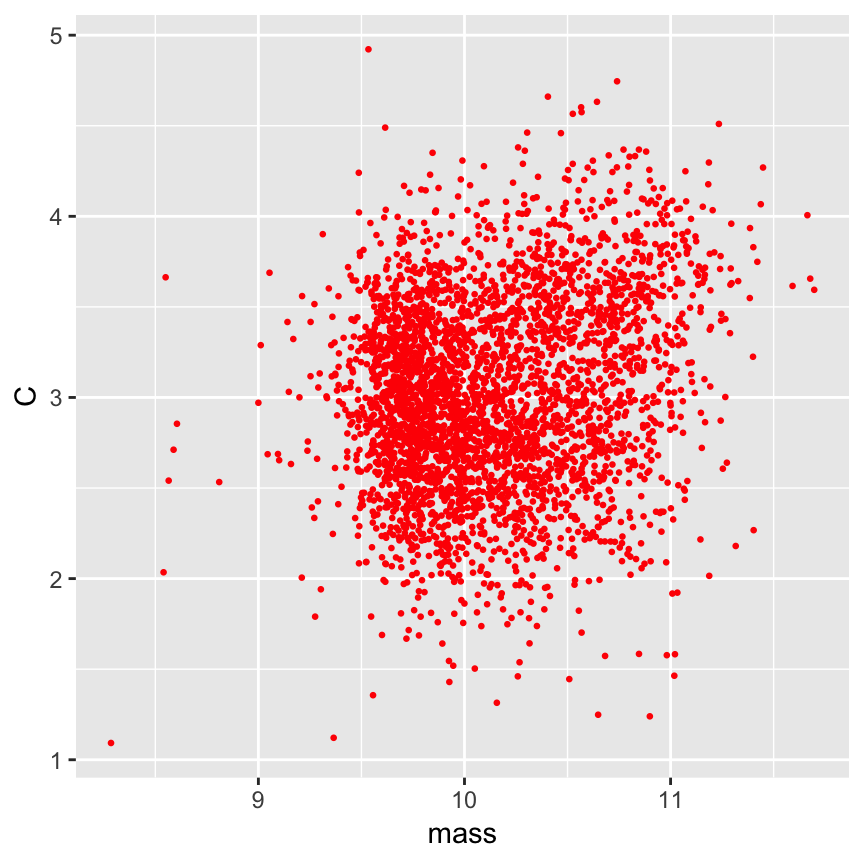

```r
ggplot(data=df,mapping=aes(x=mass,y=C)) + geom_point(color="red",size=0.5)
```

# Covariance and Correlation

Covariance is a measure of the *linear* dependence between two variables. (To be “uncorrelated” is not the same as to be “independent”…the latter means there is no dependence, linear or otherwise, between two variables.) Correlation is a “normalized” form of covariance, that ranges from -1 (one variable linearly decreases absolutely in value while the other increases in value) through 0 (no linear dependence) to 1 (one variable linear increases absolutely while the other increases).

A good package for visualizing correlation is `corrplot`:

```r
if ( require(corrplot) == FALSE ) {
  install.packages("corrplot",repos="https://cloud.r-project.org")
  library(corrplot)
}
```

# corrplot: Correlation Plot

Here we generate the correlation plot for `M20`, `A`, and `z.mode`:

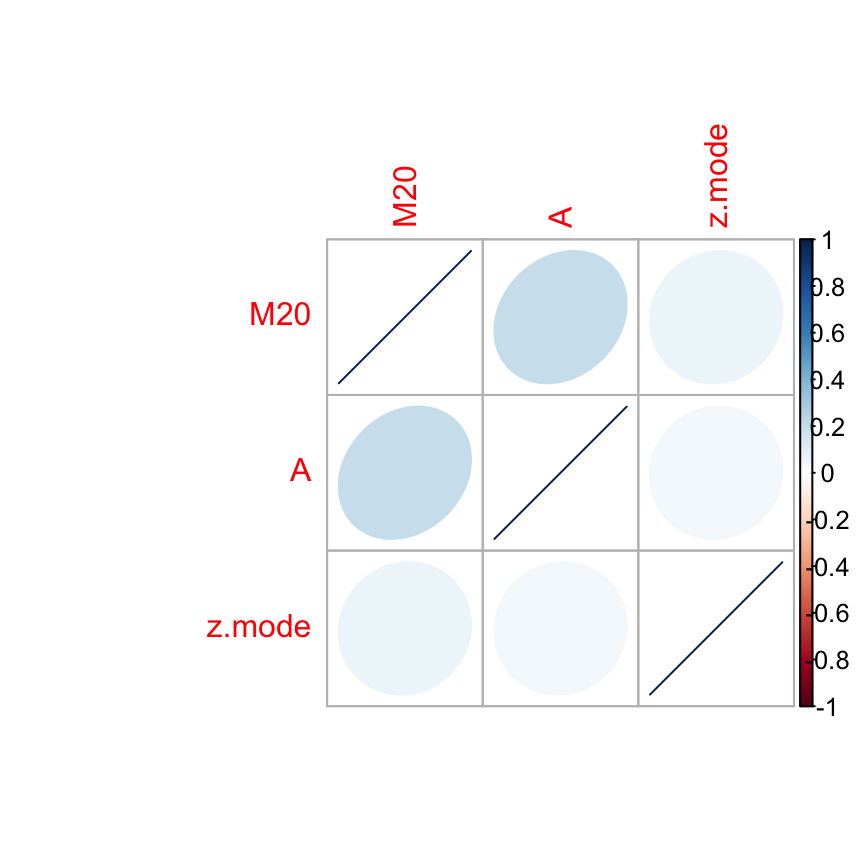

```r
corrplot(cor(df[,c("M20","A","z.mode")]),method="ellipse")
```

# GGally: Pairs Plot

We step outside canonical `ggplot` plotting for now to bring you a pairs plot from the `GGally` package:

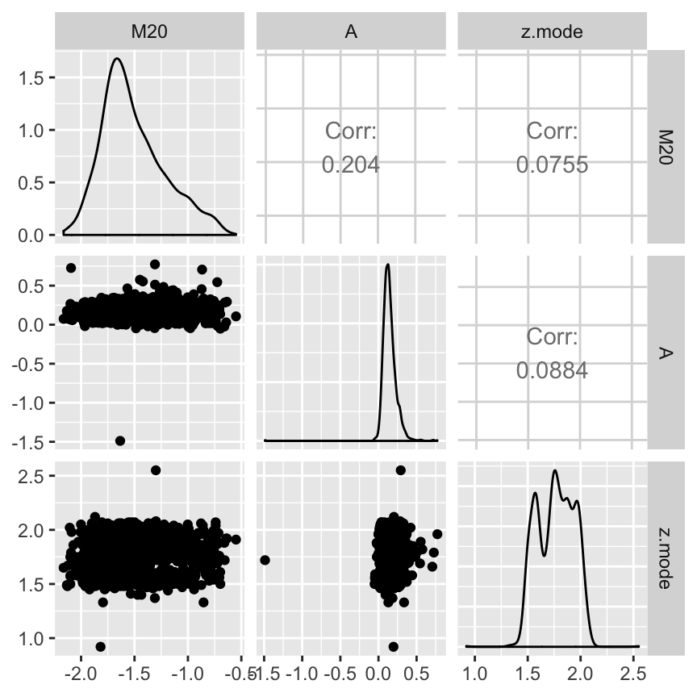

```r
if ( require(GGally) == FALSE ) {
  install.packages("GGally",repos="https://cloud.r-project.org")
  library(GGally)
}
df.new = df %>% filter(.,(field=="COSMOS"|field=="EGS")) %>% select(M20,A,z.mode)
ggpairs(df.new,progress=FALSE)
```